# ( Ford GoBike System Data )

### by ( Nourah Hasan )

## Preliminary Wrangling

### Ford GoBike is the Bay Area's bike share system, with thousands of bikes at hundreds of station in San Francisco, San Jose and the East Bay.

### What is/are the main feature(s) of interest in your dataset?

#### I am interested in How the features of members like Birth year , Gender and Type of user effected on the number of times they rides the Bike , AND effected on the length of duration trip , AND How the distance of the trip effect on counts of the times rides bike

## How the features of members like Birth year , Gender and Type of user and bike sharing effected on the number of times they rides the Bike ?

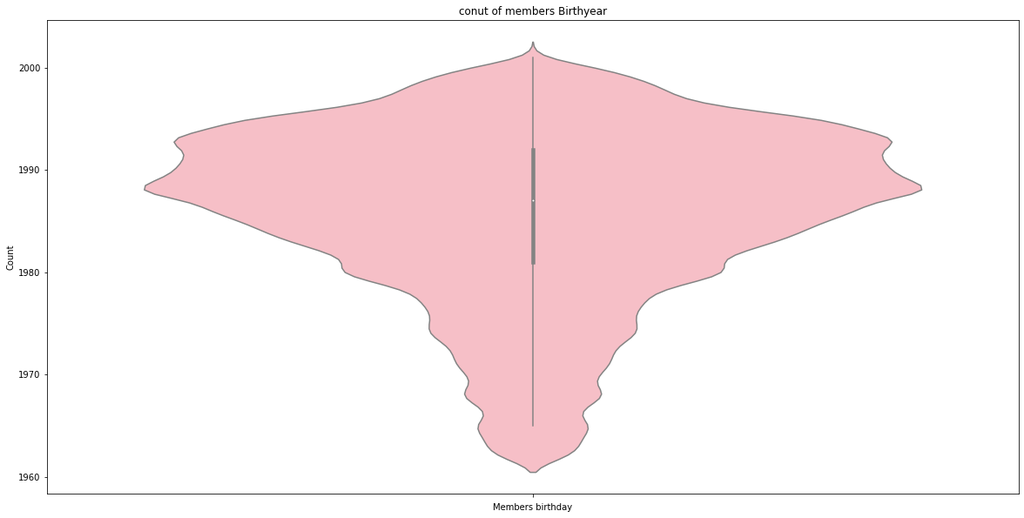

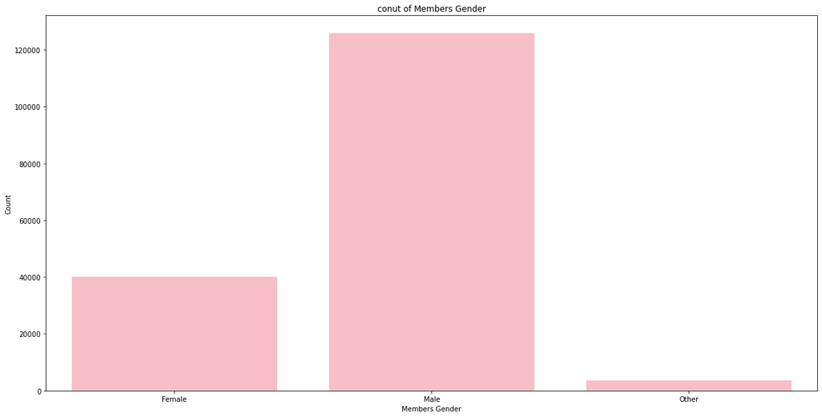

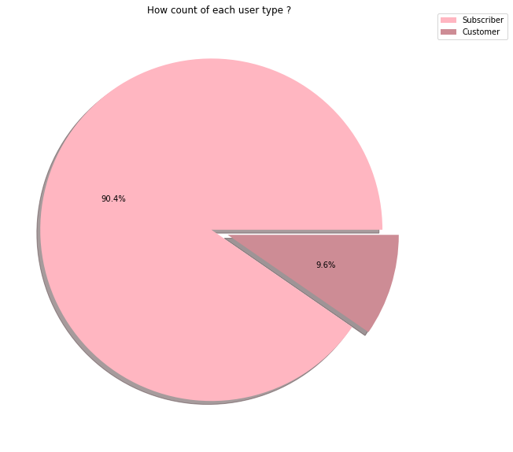

#### - The plot shows the most of user type is suscribed and the custumers are the least .

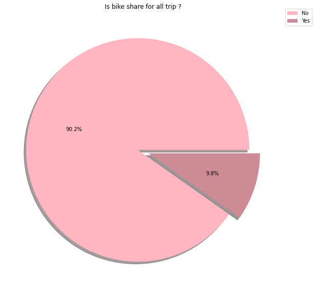

#### - It is clear from the plot that most mambers don't always use their bikes in all trip .

### correlation between member_birth_year & duration_minutes ?

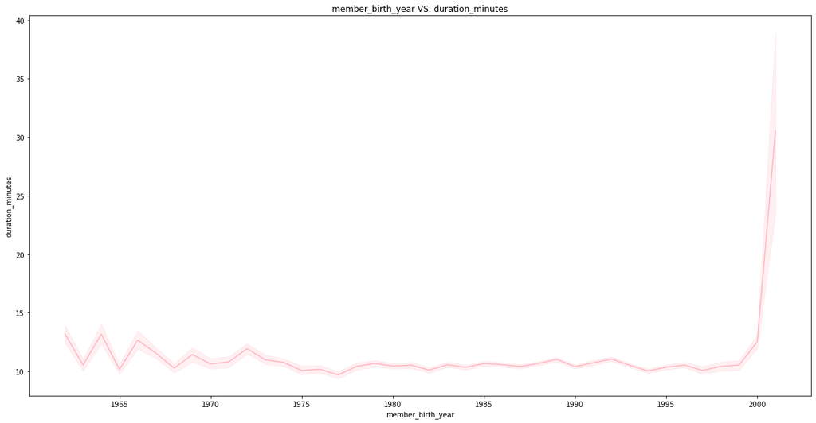

### correlation between member_birth_year & trip_distance ?

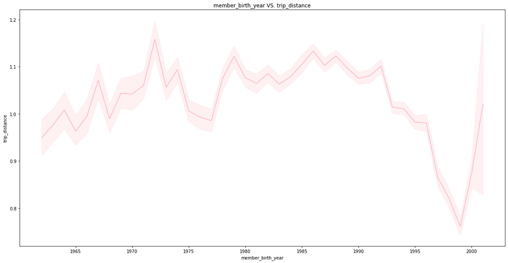

#### - The plot shows that the distance rides on the trips varies between members of all ages .

### correlation between member_gender & duration_minutes?

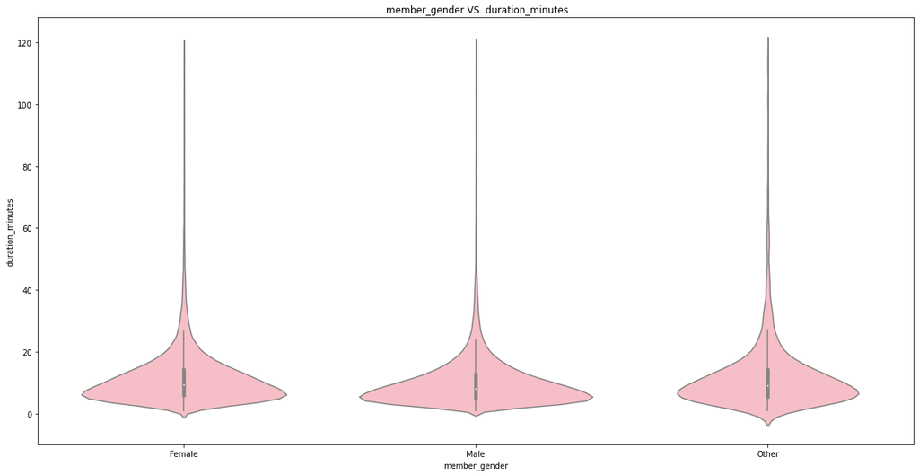

### correlation between user_type & duration_minutes?

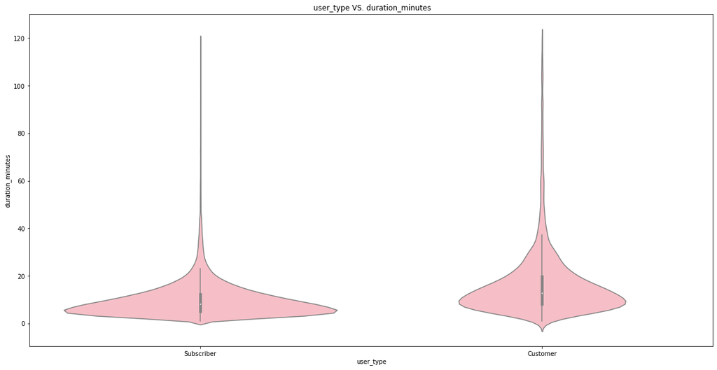

### correlation between ( user_type VS. start_hour ) & ( user_type VS. end_hour ) ?

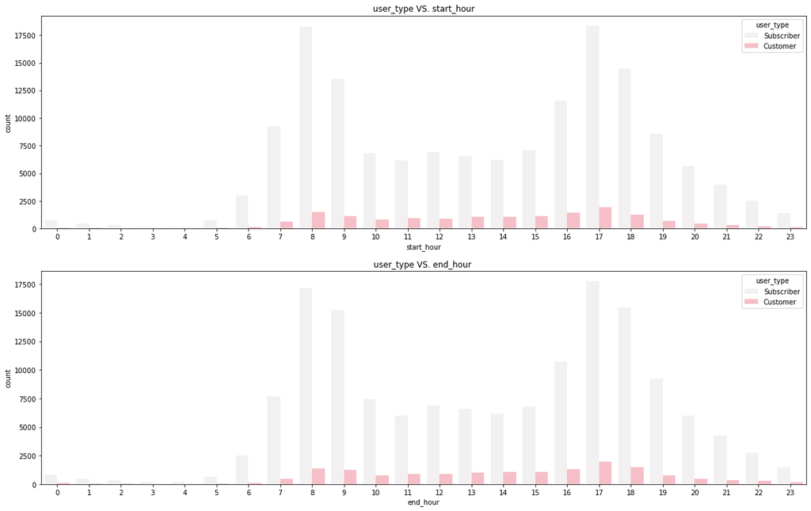

#### - we can see the times of the start hours and end hours of the (subscriber) type are higher than the times of the start and end hours of the (customer) type, the start hour and the end hour are close together .

### correlation between ( member_gender VS. start_hour ) & ( member_gender VS. end_hour ) ?

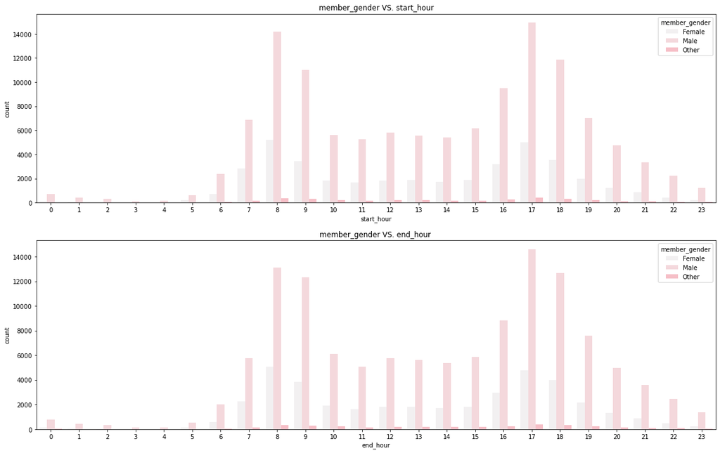

## Relationship between Duration minutes of User types for all members gender ?

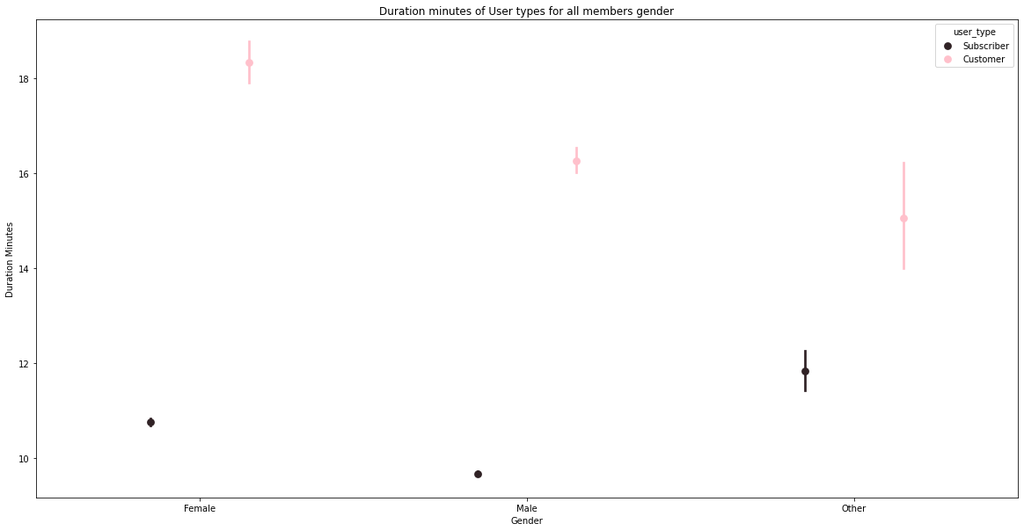

#### - we can see the suscriber type have short times of duration and on the other hand we can see the customer type have relatively longer times of duration .

## Relationship between Trip distances of User types for all members by year of birth ?

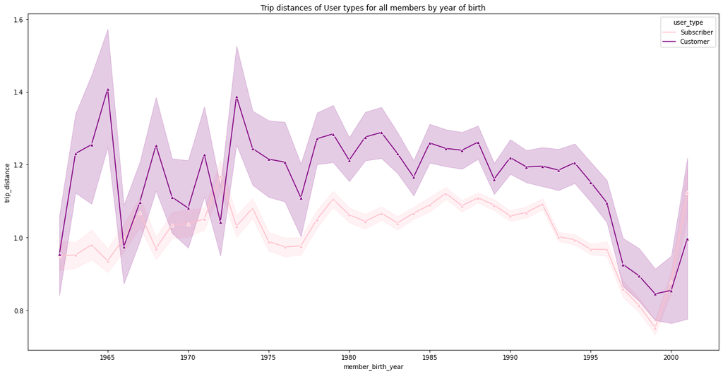